# Joseph’s Project

## Loaading the data

First, load the four data files containing the results:

```r
g90 <- read_csv("../simulations/simulations4/w=4_gamma=0.90_ptev=20_ptes_0.25_r=0_gamma.csv")
g95 <- read_csv("../simulations/simulations4/w=4_gamma=0.95_ptev=20_ptes_0.25_r=0_gamma.csv")
g90c <- read_csv("../simulations/simulations4/w=4_gamma=0.90_ptev=20_ptes_0.25_r=0_gamma_changed.csv")
g95c <- read_csv("../simulations/simulations4/w=4_gamma=0.95_ptev=20_ptes_0.25_r=0_gamma_changed.csv")
```

In some of these simulations, gamma changes after the introduction of SSRI. let’s create a new variable that records the initial value.

```r
g90$StartingGamma <- 0.9
g95$StartingGamma <- 0.95
g90c$StartingGamma <- 0.9
g95c$StartingGamma <- 0.95
```

Now, let’s create a second column/variable that records whether the simulation includes an SSRI-induced change of gamma or not (placebo).

```r
notchange <- full_join(g90, g95)
change <- full_join(g90c, g95c)
notchange$SSRI <- FALSE
change$SSRI <- TRUE
```

Finally, let;’s save the data into a single `simulations4.csv` data file.

```r
jdata <- full_join(change, notchange)
write_csv(jdata, "../simulations/simulations4.csv")
```

# Aggregating the data

The data so far is impractical to use, since it contains every event experienced by the model. We want to aggregate the events by day. If we have already done that, `CREATE_AGGREGATED` is False, and we can just load the already-created file.

```r
CREATE_AGGREGAGATED = F

if (CREATE_AGGREGAGATED) {
  d <- read_csv("../simulations/simulations4.csv")
  #d <- read_csv("simulations3.csv", col_types = cols())
  d <- d %>%
    mutate(Day = floor(Time / (60*60*24)) - 100,
           Hour = floor((d$Time / 3600) %% 24),
           RuminationFrequency=as_factor(RuminationFrequency))
  names(d)[18] <- "W"

  d <- d %>%
    dplyr::select(Run, Day, PTEV, StartingGamma, PTES, W,
                  NumAttributes, RuminationFrequency,
                  MemoryEntropy, ChunkSimilarity, Traumatic, ChunkV, SSRI) %>%
    filter(Day > -20)

  a <- d  %>%
    group_by(Run, Day, PTEV, PTES, StartingGamma,
             NumAttributes, RuminationFrequency, W, SSRI) %>%
    summarise(MemoryEntropy = mean(MemoryEntropy),
              ChunkSimilarity = mean(ChunkSimilarity),
              PTraumatic = mean(Traumatic),
              CTraumatic = sum(Traumatic),
              ChunkV = mean(ChunkV))

  write_csv(x=a, file = "../simulations/simulations4_aggregated.csv")
}

a <- read_csv(gzfile("../simulations/simulations4_aggregated.csv.gz"),
              col_types = cols())
```

### Renaming the variable

The data files record the variables with their old names, which are actually quite obscure. Let’s rename them with the names used in the paper.

```r
a <- a %>%
  rename(I = PTEV) %>%
  rename(gamma = StartingGamma) %>%
  rename(A = NumAttributes) %>%
  rename(C = PTES) %>%
  rename(R = RuminationFrequency)
```

## Recovery Trajectories

To identify a recovery trajectory, we need to first define a classification function. Here, we are going to use the following algorithm:

First the model calculates three average values:

1. The mean probability *P(baseline)* of retrieving intrusive memories in the 10 days preceding the PTE, or *baseline* period. By definition, this is always zero.
2. The mean probability *P(acute)* of retrieving intrusive memories in the 10 days following the PTE, or during the *acute* period.
3. The mean probability *P(chronic)* of retrieving intrusive memories in the last ten days of the second month after the PTE (i.e, days 51-60), or the *chronic* period.

Then, the model calculates two statistical tests:

1. A *t*-test between the baseline and acute period, or *acute test*; and
2. A *t*-test between the acute-period and the chronic period, or *chronic test*.

And finally we apply the following decision tree:

1. If the acute test is significant at p < .05 (Pacute > Pbaseline), then

   1.1. If the chronic test is also significant at *p* < .05, and Pchronic > Pacute, we classify the trajectory as **Delayed**.

   1.2. If the chronic test is significant at *p* < .05 but *P(chronic)* < *P(acute)*, then we classify the trajectory as **Recovery**;

   1.3. If the chronic test is non-significant, then *P(chronic)* ~ *P(acute)* , and we classify the trajectory as **Chronic**.
2. If, instead, the acute test is not significant and *P(acute)* ~ *P(baseline)*, then:

   2.1. If the chronic test is significant at *p* < .05, then *P(chronic)* > *P(acute)*, and we classify the trajectory as **Delayed**.

   2.2 If the chronic test is also not significant, then *P(chronic)* ~ *P(baseline)* ~ *P(acute)*, and we classify the trajectory as **Resilient**.

```r
# Classifies people based on trajectory:
# Chronic = 1
# Recovery =2
# Delay    =3
# resilient= 4
#
classify <- function(days) {
  g1 <- days[10:19]
  g2 <- days[21:30]
  g3 <- days[70:79]
  t12 <- t.test(g1, g2)
  t23 <- t.test(g2, g3)
  category <- 0
  if (!is.na(t12$p.value) & t12$p.value < 0.05) {
    # t1 < t2
    if (!is.na(t23$p.value) & t23$p.value < 0.05) {
      # t2 <> t3

      if (!is.na(t23$statistic) & t23$statistic > 0) {
        # t1 < t2, t2 > 3
        category <- "Recovery" #2  # Recovery
      } else {
        # t1 < t2, t2 < t3
        category <- "Delayed" # 3 # Delayed
      }
    } else {
      # t1 < t2, t2 = t3
      category <- "Chronic" # 1 # Chronic
    }
  } else {
    # t1 == t2
    if (!is.na(t23$p.value) & t23$p.value < 0.05) {
      # t1 == t2, t2 < t3
      category <- "Delayed" #3 # Delayed
    } else {
      # t1 == t2, t2 = t3
      category <- "Resilient" # 4 # Resilient
    }
  }
  category
}

patterns <- a %>%
  group_by(Run, gamma, SSRI) %>%
  dplyr::summarize(Trajectory = classify(PTraumatic))
patterns <- patterns %>% ungroup
```

Finally, let’s assign each data point in the main averages with the corresponding trajectory, and re-order the trajectories in order of severity:

```r
a <- inner_join(a, patterns)
a$Trajectory <- factor(a$Trajectory,
                      levels = c("Recovery", "Delayed", "Resilient",  "Chronic"))
```

# Results

Here we visualize the effects of SSRIs on the traumatic intrusions.

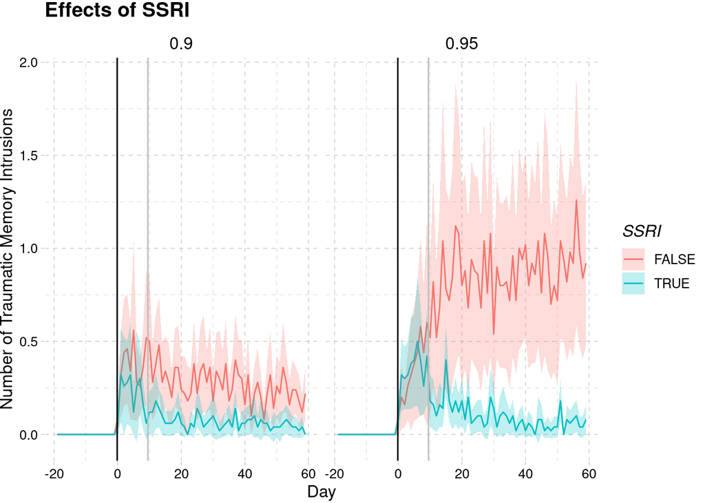

```r
#a$gamma <- as_factor(a$gamma)
ggplot(data = a,
       aes(x = Day, y = CTraumatic, fill = SSRI, col = SSRI)) +
  #geom_smooth(method="loess", span=0.2) +
  stat_summary(fun.data = mean_se, geom="line") +
  stat_summary(fun.data = mean_cl_normal,
               geom="ribbon", alpha = 0.25, col=NA) +

  facet_wrap(~ gamma) +
  ggtitle("Effects of SSRI") +
  ylab("Number of Traumatic Memory Intrusions") +

  geom_vline(data=a, aes(xintercept=-0.15)) +
  geom_vline(data=a, aes(xintercept=9.5), col="grey") +
  theme_pander()
```